# Ordination

Michael Liou

2022-07-28

> The following document is a work in progress!

# Overview

Methods to Distinguish

- Correspondance Analysis (CA)
  - unconstrained, compare to PCA
- Redundancy Analysis (RDA)
- Canonical correspondance Analysis (CCA)
- Canonical Correlation Analysis (CCorA)
- Discriminant Analysis (DA)
- PCA
- Factor Analysis
- NMDS
- MDS

General Packages

- `PCA::`

Software functions

- `prcomp` - PCA
- `princomp` - PCA
- `cmdscale()` - mds
- `factanal()` - factor analysis
- `labdsv::pca`
- `ade4::`

# Organizing Types of Ecological Data

An ecological data matrix generally has the format of a main “response” matrix, with counts of species (columns) at each site (rows). We will generally have another data frame with the covariates describing each site, called the “environmental covariate” matrix and “species covariates” matrix.

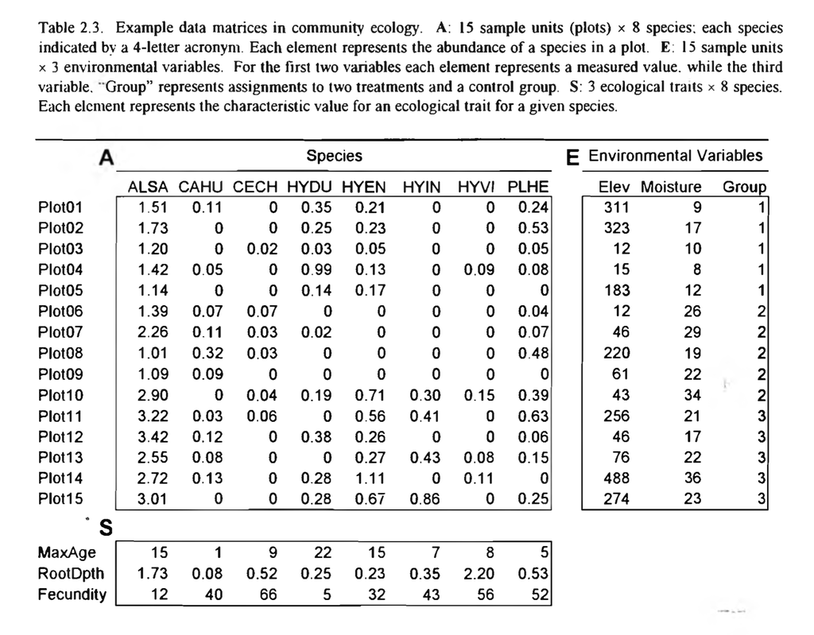

# PCA

We’ll use USArrests example to show the similarity between all the program functionality

```r
USArrests %>% head() # This is what the data looks like
```

```
##            Murder Assault UrbanPop Rape
## Alabama      13.2     236       58 21.2
## Alaska       10.0     263       48 44.5
## Arizona       8.1     294       80 31.0
## Arkansas      8.8     190       50 19.5
## California    9.0     276       91 40.6
## Colorado      7.9     204       78 38.7
```

## prcomp

`prcomp` uses `svd` under the hood, and is generally the main workhorse for doing principal components analysis.

```r
us_pr <- prcomp(USArrests, scale = TRUE)
us_pr$sdev^2 # the variances
```

```
## [1] 2.4802416 0.9897652 0.3565632 0.1734301
```

```r
us_pr$rotation
```

```
##                 PC1        PC2        PC3         PC4
## Murder   -0.5358995  0.4181809 -0.3412327  0.64922780
## Assault  -0.5831836  0.1879856 -0.2681484 -0.74340748
## UrbanPop -0.2781909 -0.8728062 -0.3780158  0.13387773
## Rape     -0.5434321 -0.1673186  0.8177779  0.08902432
```

## eigen

```r
us_Y <- cov(USArrests %>% scale(center = TRUE, scale = TRUE))
us_Y <- cor(USArrests) # the same as cov of centered matrix

us_eig <- eigen(us_Y)
# variances
us_eig$values
```

```
## [1] 2.4802416 0.9897652 0.3565632 0.1734301
```

```r
us_eig$vectors # loadings
```

```
##            [,1]       [,2]       [,3]        [,4]
## [1,] -0.5358995  0.4181809 -0.3412327  0.64922780
## [2,] -0.5831836  0.1879856 -0.2681484 -0.74340748
## [3,] -0.2781909 -0.8728062 -0.3780158  0.13387773
## [4,] -0.5434321 -0.1673186  0.8177779  0.08902432
```

## princomp

uses `eigen` under the hood, mostly here for compatibility reasons

```r
# correlation version
us_prin <- princomp(USArrests, cor = TRUE)
us_prin$sdev^2
```

```
##    Comp.1    Comp.2    Comp.3    Comp.4
## 2.4802416 0.9897652 0.3565632 0.1734301
```

```r
# loadings
us_prin$loadings
```

```
##
## Loadings:
##          Comp.1 Comp.2 Comp.3 Comp.4
## Murder    0.536  0.418  0.341  0.649
## Assault   0.583  0.188  0.268 -0.743
## UrbanPop  0.278 -0.873  0.378  0.134
## Rape      0.543 -0.167 -0.818
##
##                Comp.1 Comp.2 Comp.3 Comp.4
## SS loadings      1.00   1.00   1.00   1.00
## Proportion Var   0.25   0.25   0.25   0.25
## Cumulative Var   0.25   0.50   0.75   1.00
```

```r
# these scores should be the same, can't figure out why they're slightly different?
us_prin$scores %>% head()
```

```
##                Comp.1     Comp.2      Comp.3       Comp.4
## Alabama     0.9855659  1.1333924  0.44426879  0.156267145
## Alaska      1.9501378  1.0732133 -2.04000333 -0.438583440
## Arizona     1.7631635 -0.7459568 -0.05478082 -0.834652924
## Arkansas   -0.1414203  1.1197968 -0.11457369 -0.182810896
## California  2.5239801 -1.5429340 -0.59855680 -0.341996478
## Colorado    1.5145629 -0.9875551 -1.09500699  0.001464887
```

```r
scale(USArrests) %*% us_eig$vectors %>% head()
```

```
##                  [,1]       [,2]        [,3]         [,4]
## Alabama    -0.9756604  1.1220012 -0.43980366  0.154696581
## Alaska     -1.9305379  1.0624269  2.01950027 -0.434175454
## Arizona    -1.7454429 -0.7384595  0.05423025 -0.826264240
## Arkansas    0.1399989  1.1085423  0.11342217 -0.180973554
## California -2.4986128 -1.5274267  0.59254100 -0.338559240
## Colorado   -1.4993407 -0.9776297  1.08400162  0.001450164
```

```r
# the scale variables
cbind(us_prin$center,
      attr(scale(USArrests), "scaled:center"))
```

```
##             [,1]    [,2]
## Murder     7.788   7.788
## Assault  170.760 170.760
## UrbanPop  65.540  65.540
## Rape      21.232  21.232
```

```r
n <- nrow(USArrests)
cbind(us_prin$scale,
      attr(scale(USArrests), "scaled:scale") * sqrt((n-1) / n))
```

```
##               [,1]      [,2]
## Murder    4.311735  4.311735
## Assault  82.500075 82.500075
## UrbanPop 14.329285 14.329285
## Rape      9.272248  9.272248
```

```r
# covariance version
us_prin_cov <- princomp(USArrests) # uses factor of 1/n for variance calculations

# the svd equivalent
n <- nrow(USArrests)
us_svd_cov <- svd(cov(USArrests) * (n-1) / n)

cbind(us_prin_cov$sdev^2,
      us_svd_cov$d)
```

```
##               [,1]        [,2]
## Comp.1 6870.892554 6870.892554
## Comp.2  197.952519  197.952519
## Comp.3   41.270398   41.270398
## Comp.4    6.040961    6.040961
```

only works for when n > p, “R”-mode PCA refers to the respondents (rows) and “Q”-mode refers to the questions (columns). difference is just interpretation. SVD is prefered

## svd

$$\begin{aligned}
\Sigma = UDV' \\
U'\Sigma = DV'
\end{aligned}$$

```r
us_Y <- cov(USArrests %>% scale(center = TRUE, scale = TRUE))
us_Y <- cor(USArrests) # the same as cov of centered matrix

us_svd <- svd(us_Y)

# UDV'
# us_svd$u %*% diag(us_svd$d) %*% t(us_svd$v)


us_svd$d # the variances
```

```
## [1] 2.4802416 0.9897652 0.3565632 0.1734301
```

```r
us_svd$v # the loadings
```

```
##            [,1]       [,2]       [,3]        [,4]
## [1,] -0.5358995  0.4181809 -0.3412327  0.64922780
## [2,] -0.5831836  0.1879856 -0.2681484 -0.74340748
## [3,] -0.2781909 -0.8728062 -0.3780158  0.13387773
## [4,] -0.5434321 -0.1673186  0.8177779  0.08902432
```

# Correspondence Analysis (CA)

- `ca::ca()`
- `FactoMineR::CA()`
- `ade4::dudi.coa()`
- `amap::afc()`
- `MASS::corresp()`

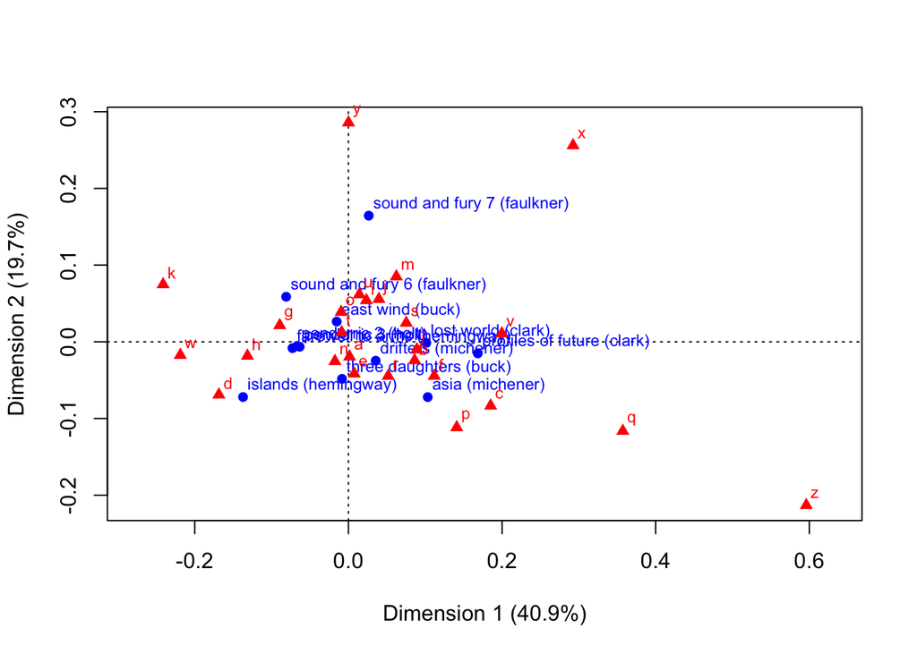

```r
author_ca <- ca(author)
plot(author_ca)
```

# Multivariate Regression

`lm` can handle multivariate regressions

## Estimation

$$\begin{aligned}
\hat B = (X'X)^{-1}X'Y
\end{aligned}$$
We can also formulate the answers w/ the centered $X$ matrix
$$\begin{aligned}
\mathbf{\hat B_1} &=
(\mathbf{X_c}'\mathbf{X_c})^{-1}\mathbf{X_c}'\mathbf{Y} \\
\mathbf{\hat \beta_0} &= \mathbf{\bar y} - \mathbf{\bar
x}'\mathbf{\hat B_1}
\end{aligned}$$

```r
iris_lm <- lm(cbind(Sepal.Length, Sepal.Width, Petal.Length, Petal.Width)~Species, data = iris)
```

```r
# Useful for manual calculations
Y <- with(iris, cbind(Sepal.Length, Sepal.Width, Petal.Length, Petal.Width))
X <- model.matrix(~Species, data = iris)
X1 <- X[,-1] # drop the intercept
Xc <- X1 %>% scale(scale = F)
SYY <- cov(Y)
SYX <- cov(Y, X1)
SXX <- cov(X1)
```

```r
# Manual calculation of B
B <- solve(crossprod(X)) %*% t(X) %*% Y # B

# B calculation with centered matrices
B1 <- solve(crossprod(Xc)) %*% t(Xc) %*% Y # B_1
B0 <- colMeans(Y) - t(colMeans(X1)) %*% B1


# B calculation w/ covariances
B1_S <- solve(SXX) %*% t(SYX)
B0_S <- colMeans(Y) -  t(colMeans(X1)) %*% B1_S

list(lm = coef(iris_lm),
     manual = B,
     centered = rbind(B0, B1),
     covariance = rbind(B0_S, B1_S))
```

```
## $lm
##                   Sepal.Length Sepal.Width Petal.Length Petal.Width
## (Intercept)              5.006       3.428        1.462       0.246
## Speciesversicolor        0.930      -0.658        2.798       1.080
## Speciesvirginica         1.582      -0.454        4.090       1.780
##
## $manual
##                   Sepal.Length Sepal.Width Petal.Length Petal.Width
## (Intercept)              5.006       3.428        1.462       0.246
## Speciesversicolor        0.930      -0.658        2.798       1.080
## Speciesvirginica         1.582      -0.454        4.090       1.780
##
## $centered
##                   Sepal.Length Sepal.Width Petal.Length Petal.Width
##                          5.006       3.428        1.462       0.246
## Speciesversicolor        0.930      -0.658        2.798       1.080
## Speciesvirginica         1.582      -0.454        4.090       1.780
##
## $covariance
##                   Sepal.Length Sepal.Width Petal.Length Petal.Width
##                          5.006       3.428        1.462       0.246
## Speciesversicolor        0.930      -0.658        2.798       1.080
## Speciesvirginica         1.582      -0.454        4.090       1.780
```

$$\begin{aligned}
R^2 = \frac{|S_{XY} S_{XX}^{-1} S_{YX}|}{|S_{YY}|}
\end{aligned}$$

```r
# TODO: Why is R^2 zero here
# R^2 from each regression
# vapply(summary(iris_lm),FUN = function(x) x$r.squared, FUN.VALUE = numeric(1))

det(SYX %*% solve(SXX) %*% t(SYX)) / det(SYY) # way small, basically 0
```

```
## [1] 4.449697e-31
```

## Hypothesis Testing

Consider the partitioning, from pg 343 of Rencher Methods of Multivariate Analysis

$$\begin{aligned}
\mathbf{Y'Y} - n\mathbf{\bar y\bar y'} &= (\mathbf{Y'Y}
+ \mathbf{Y'X'\hat{B}}) - (\mathbf{Y'X'\hat{B}}
- n\mathbf{\bar y\bar y'}) \\
&\equiv \mathbf{E} + \mathbf{H}
\end{aligned}$$

In hypothesis testing, the matrix $E^{-1}H$ is pretty special, and many of the tests can be expressed in terms of the eigenvalues of this matrix. Hence, let $\lambda_i$ be the $i$th largest eigenvalue of $E^{-1}H$.

- Wilks Hypothesis Test $\Lambda = \frac{|E|}{|E + H|}$ (likelihood ratio test)
  - on the eigenscale: $\Lambda = \prod_{i=1}^s \frac{1}{1+\lambda_i}$
  - with covariance: $\Lambda = \frac{|\mathbf{S}|}{|\mathbf{S_{XX}}|\mathbf{S_{YY}}|}$
- Roy
  - on the eigenscale $\theta = \frac{\lambda_1}{1 + \lambda_1}$
- Pillai $V^{(s)} = \mathrm{tr}[(H + E)^{-1}H]$
  - on the eigenscale: $V^{(s)} = \sum_i^s\frac{\lambda_i}{1 + \lambda_i}$
- Hotelling (generalized T statistic) $U^{(s)} = tr(E^{-1}H)$
  - on the eigenscale: $U^{(s)} = \sum_i^s \lambda_i$

# Redundancy Analysis

Redundancy analysis can be understood as a multivariate regression followed by a PCA on the (covariance) of the fitted values.

It seems I’m running into a bunch of singularity issues due to the fact that n < p in these matrices, the standard eigenequation of redundancy analysis is:

$$\begin{aligned}
(S_{YX}S^{-1}_{XX}S'_{YX} - \lambda_k I)u_k = 0
\end{aligned}$$

The ecological matrix `dune` is matrix counts of 30 species (columns) from 20 sites (rows). The covariate matrix `dune.env` is covariates of the 20 sites (rows), with 5 features of the site (columns):

- A1: numeric vector of soil thickness on A1 horizon
- Moisture: ordered factor with levels 1 < 2 < 4 < 5
- Type of management
- Use - land-use Hayfield < Hyapastu < Pasture
- Manure - ordered factor

```r
data(dune)
data(dune.env)

dune %>% head()
```

```
##   Achimill Agrostol Airaprae Alopgeni Anthodor Bellpere Bromhord Chenalbu
## 1        1        0        0        0        0        0        0        0
## 2        3        0        0        2        0        3        4        0
## 3        0        4        0        7        0        2        0        0
## 4        0        8        0        2        0        2        3        0
## 5        2        0        0        0        4        2        2        0
## 6        2        0        0        0        3        0        0        0
##   Cirsarve Comapalu Eleopalu Elymrepe Empenigr Hyporadi Juncarti Juncbufo
## 1        0        0        0        4        0        0        0        0
## 2        0        0        0        4        0        0        0        0
## 3        0        0        0        4        0        0        0        0
## 4        2        0        0        4        0        0        0        0
## 5        0        0        0        4        0        0        0        0
## 6        0        0        0        0        0        0        0        0
##   Lolipere Planlanc Poaprat Poatriv Ranuflam Rumeacet Sagiproc Salirepe
## 1        7        0       4       2        0        0        0        0
## 2        5        0       4       7        0        0        0        0
## 3        6        0       5       6        0        0        0        0
## 4        5        0       4       5        0        0        5        0
## 5        2        5       2       6        0        5        0        0
## 6        6        5       3       4        0        6        0        0
##   Scorautu Trifprat Trifrepe Vicilath Bracruta Callcusp
## 1        0        0        0        0        0        0
## 2        5        0        5        0        0        0
## 3        2        0        2        0        2        0
## 4        2        0        1        0        2        0
## 5        3        2        2        0        2        0
## 6        3        5        5        0        6        0
```

```r
dune.env %>% head()
```

```
##    A1 Moisture Management      Use Manure
## 1 2.8        1         SF Haypastu      4
## 2 3.5        1         BF Haypastu      2
## 3 4.3        2         SF Haypastu      4
## 4 4.2        2         SF Haypastu      4
## 5 6.3        1         HF Hayfield      2
## 6 4.3        1         HF Haypastu      2
```

```r
dune_rda <- rda(dune ~ Manure, dune.env, scale = T)
dune_rda
```

```
## Call: rda(formula = dune ~ Manure, data = dune.env, scale = T)
##
##               Inertia Proportion Rank
## Total         30.0000     1.0000
## Constrained    8.7974     0.2932    4
## Unconstrained 21.2026     0.7068   15
## Inertia is correlations
##
## Eigenvalues for constrained axes:
##  RDA1  RDA2  RDA3  RDA4
## 4.374 2.078 1.449 0.896
##
## Eigenvalues for unconstrained axes:
##   PC1   PC2   PC3   PC4   PC5   PC6   PC7   PC8   PC9  PC10  PC11  PC12  PC13
## 5.133 3.447 2.462 1.924 1.662 1.366 1.357 0.926 0.839 0.585 0.511 0.439 0.308
##  PC14  PC15
## 0.159 0.084
```

```r
summary(dune_rda)
```

```
##
## Call:
## rda(formula = dune ~ Manure, data = dune.env, scale = T)
##
## Partitioning of correlations:
##               Inertia Proportion
## Total          30.000     1.0000
## Constrained     8.797     0.2932
## Unconstrained  21.203     0.7068
##
## Eigenvalues, and their contribution to the correlations
##
## Importance of components:
##                         RDA1    RDA2    RDA3    RDA4    PC1    PC2     PC3
## Eigenvalue            4.3740 2.07784 1.44948 0.89609 5.1334 3.4467 2.46206
## Proportion Explained  0.1458 0.06926 0.04832 0.02987 0.1711 0.1149 0.08207
## Cumulative Proportion 0.1458 0.21506 0.26338 0.29325 0.4644 0.5793 0.66132
##                           PC4     PC5     PC6     PC7     PC8     PC9    PC10
## Eigenvalue            1.92357 1.66179 1.36650 1.35737 0.92607 0.83920 0.58545
## Proportion Explained  0.06412 0.05539 0.04555 0.04525 0.03087 0.02797 0.01952
## Cumulative Proportion 0.72544 0.78083 0.82638 0.87163 0.90250 0.93047 0.94999
##                          PC11    PC12    PC13     PC14     PC15
## Eigenvalue            0.51113 0.43886 0.30750 0.158961 0.083959
## Proportion Explained  0.01704 0.01463 0.01025 0.005299 0.002799
## Cumulative Proportion 0.96702 0.98165 0.99190 0.997201 1.000000
##
## Accumulated constrained eigenvalues
## Importance of components:
##                         RDA1   RDA2   RDA3   RDA4
## Eigenvalue            4.3740 2.0778 1.4495 0.8961
## Proportion Explained  0.4972 0.2362 0.1648 0.1019
## Cumulative Proportion 0.4972 0.7334 0.8981 1.0000
##
## Scaling 2 for species and site scores
## * Species are scaled proportional to eigenvalues
## * Sites are unscaled: weighted dispersion equal on all dimensions
## * General scaling constant of scores:  4.886172
##
##
## Species scores
```

[output cut: 86 more lines]

```
##             RDA1    RDA2    RDA3    RDA4 PC1 PC2
## Manure.L  0.7227 -0.6209  0.2738 -0.1315   0   0
## Manure.Q -0.5907 -0.4981 -0.5890 -0.2369   0   0
## Manure.C  0.5983  0.2084 -0.7428  0.2166   0   0
## Manure^4  0.1381  0.4330 -0.1116 -0.8837   0   0
##
##
## Centroids for factor constraints
##
##             RDA1    RDA2    RDA3    RDA4 PC1 PC2
## Manure0 -1.55162  0.1903 -0.4719 -0.3449   0   0
## Manure1  0.72183  0.8482 -1.0417  2.1068   0   0
## Manure2  1.02356  1.4013  0.5966 -1.1865   0   0
## Manure3 -0.06573 -0.9527  1.8209  0.7398   0   0
## Manure4  1.10430 -1.8270 -1.2379 -0.8214   0   0
```

```r
scores(dune_rda, scaling = 0, display = "sp")
```

```
##                  RDA1        RDA2
## Achimill  0.143458988  0.25880807
## Agrostol -0.014318256 -0.32220859
## Airaprae -0.221477424  0.03941836
## Alopgeni  0.182994436 -0.16391065
## Anthodor -0.032899432  0.24552799
## Bellpere  0.170004691  0.05561525
## Bromhord  0.194470873  0.10200638
## Chenalbu -0.006598932 -0.13878455
## Cirsarve  0.110871155 -0.26612997
## Comapalu -0.226345641  0.04028481
## Eleopalu -0.199452547 -0.12368720
## Elymrepe  0.278156602 -0.08806907
## Empenigr -0.155781754  0.02772590
## Hyporadi -0.171282469  0.07992401
## Juncarti -0.116954796 -0.03910985
## Juncbufo  0.107686567  0.09944215
## Lolipere  0.319690365 -0.12781833
## Planlanc  0.074625723  0.25548840
## Poaprat   0.308361280 -0.17154631
## Poatriv   0.327251488 -0.06646981
## Ranuflam -0.244850313 -0.11632722
## Rumeacet  0.181152477  0.30802177
## Sagiproc  0.109442555 -0.07068686
## Salirepe -0.274766547  0.04890272
## Scorautu -0.072918338  0.32138155
## Trifprat  0.127920010  0.20855494
## Trifrepe  0.116609271  0.37888351
## Vicilath  0.026342810  0.17029063
## Bracruta -0.052193007  0.20359595
## Callcusp -0.200951405 -0.04022983
## attr(,"const")
## [1] 4.886172
```

```r
Y <- dune %>% data.matrix()
X <- model.matrix(~Manure, data = dune.env)[,-1, drop = F]
# Y <- dune %>% scale(scale = T)

SYY <- cov(Y)

SXX <- cov(X)
SYX <- cov(Y, X)
rbind(cbind(SYY, SYX),
      cbind(t(SYX), SXX))
```

```
##             Achimill    Agrostol    Airaprae    Alopgeni    Anthodor
## Achimill  1.53684211 -2.02105263  0.00000000 -1.20000000  1.32631579
## Agrostol -2.02105263  7.20000000 -0.63157895  3.76842105 -2.65263158
## Airaprae  0.00000000 -0.63157895  0.61842105 -0.47368421  0.77631579
## Alopgeni -1.20000000  3.76842105 -0.47368421  6.90526316 -1.98947368
## Anthodor  1.32631579 -2.65263158  0.77631579 -1.98947368  2.89210526
## Bellpere  0.55789474 -0.37894737 -0.17105263  0.03157895  0.12368421
## Bromhord  1.26315789 -0.63157895 -0.19736842 -0.68421053  0.64473684
## Chenalbu -0.04210526  0.13684211 -0.01315789  0.16842105 -0.05526316
## Cirsarve -0.08421053  0.58947368 -0.02631579  0.02105263 -0.11052632
## Comapalu -0.16842105  0.33684211 -0.05263158 -0.37894737 -0.22105263
## Eleopalu -1.05263158  3.57894737 -0.32894737  0.36842105 -1.38157895
## Elymrepe  0.16842105  0.18947368 -0.34210526  0.80000000 -0.59473684
## Empenigr -0.08421053 -0.25263158  0.28947368 -0.18947368  0.31052632
## Hyporadi -0.16842105 -1.13684211  0.88157895 -0.85263158  0.97631579
## Juncarti -0.75789474  1.98947368 -0.23684211  0.61052632 -0.99473684
## Juncbufo -0.33684211  0.62105263 -0.17105263  1.87368421 -0.50789474
## Lolipere  1.45263158 -2.80000000 -0.76315789 -0.86315789  0.05789474
## Planlanc  1.32631579 -3.28421053 -0.13157895 -2.46315789  1.98421053
## Poaprat   0.71578947 -1.32631579 -0.52631579  0.34736842 -0.28421053
## Poatriv   0.97894737  0.98947368 -0.82894737  3.82105263 -0.21842105
## Ranuflam -0.58947368  1.81052632 -0.18421053  0.14736842 -0.77368421
## Rumeacet  0.71578947 -1.53684211 -0.23684211 -0.54736842  1.32105263
## Sagiproc -0.84210526  1.68421053  0.21052632  1.68421053 -0.47368421
## Salirepe -0.46315789 -0.07368421  0.32894737 -1.04210526  0.02368421
## Scorautu  0.30526316 -2.29473684  0.44736842 -1.16842105  0.75263158
## Trifprat  0.56842105 -1.13684211 -0.11842105 -0.85263158  0.92368421
## Trifrepe  1.02105263 -1.56842105 -0.30263158 -0.29473684  0.50789474
## Vicilath  0.04210526 -0.50526316 -0.05263158 -0.37894737 -0.01052632
## Bracruta -0.58947368  0.02105263 -0.17105263 -0.32631579 -0.07631579
## Callcusp -0.42105263  1.47368421 -0.13157895 -0.31578947 -0.55263158
## Manure.L  0.00000000  0.38280203 -0.14563121  0.63245553 -0.21220547
## Manure.Q -0.23068865  0.22224882  0.13011403 -0.34321970 -0.10057463
## Manure.C  0.11650497 -0.24965350 -0.06241337 -0.06657427  0.02080446
## Manure^4  0.10694151 -0.24533640  0.02359004 -0.05032542  0.13053155
##             Bellpere    Bromhord     Chenalbu     Cirsarve    Comapalu
## Achimill  0.55789474  1.26315789 -0.042105263 -0.084210526 -0.16842105
## Agrostol -0.37894737 -0.63157895  0.136842105  0.589473684  0.33684211
## Airaprae -0.17105263 -0.19736842 -0.013157895 -0.026315789 -0.05263158
## Alopgeni  0.03157895 -0.68421053  0.168421053  0.021052632 -0.37894737
```

[output cut: 190 more lines]

```
## Poatriv   0.87794814 -0.765914454  0.11234407  0.045607407
## Ranuflam -0.10818318  0.111124411 -0.27461885 -0.122668199
## Rumeacet  0.09153962 -0.474037045  0.04160892  0.336551214
## Sagiproc  0.14979210 -0.042199143  0.11650497 -0.031453384
## Salirepe -0.32038866  0.286250856 -0.13730942  0.051898084
## Scorautu -0.30790598 -0.085804925  0.04160892  0.097505492
## Trifprat  0.07073516 -0.244051713 -0.02912624  0.199728991
## Trifrepe -0.17059656 -0.380495610  0.26213617  0.127386207
## Vicilath -0.06657427 -0.022506210  0.09986140 -0.075488123
## Bracruta -0.22884904 -0.075255139 -0.01248267  0.105368838
## Callcusp -0.14147032  0.133630621 -0.17475745 -0.047180077
## Manure.L  0.21973684 -0.054490209  0.01447368 -0.017406259
## Manure.Q -0.05449021  0.220112782 -0.01445659 -0.004623449
## Manure.C  0.01447368 -0.014456586  0.18815789  0.012433042
## Manure^4 -0.01740626 -0.004623449  0.01243304  0.198308271
```

```r
solve(SXX) %*% t(SYX)
```

```
##            Achimill   Agrostol    Airaprae      Alopgeni   Anthodor   Bellpere
## Manure.L -0.2635231  2.1081851 -0.52704628  2.687936e+00 -1.1067972 0.42163702
## Manure.Q -1.0690450  1.4253933  0.44543540 -9.354143e-01 -0.7126966 0.04454354
## Manure.C  0.5270463 -1.3176157 -0.26352314 -6.324555e-01  0.1054093 0.73786479
## Manure^4  0.4581710 -0.9362624  0.09960238 -3.330669e-16  0.5378529 0.77689860
##            Bromhord    Chenalbu   Cirsarve    Comapalu   Eleopalu  Elymrepe
## Manure.L  0.3689324  0.07905694 0.42163702 -0.42163702 -0.4216370 1.8973666
## Manure.Q -0.7572402 -0.06681531 0.35634832  0.35634832  0.3563483 0.5345225
## Manure.C  0.8432740 -0.15811388 0.21081851 -0.21081851 -2.5825268 2.5298221
## Manure^4  0.3187276 -0.11952286 0.07968191  0.07968191 -1.1753081 0.9561829
##             Empenigr    Hyporadi   Juncarti    Juncbufo   Lolipere   Planlanc
## Manure.L -0.21081851 -0.94868330 -0.6061032 -0.02635231  2.7933453 -0.7642171
## Manure.Q  0.17817416  0.44543540 -0.2004459 -1.22494736 -0.3563483 -1.7594698
## Manure.C -0.10540926  0.05270463 -0.6324555  0.05270463  3.3730962  0.2108185
## Manure^4  0.03984095 -0.17928429 -1.3346719 -0.51793240 -0.4980119  0.3386481
##             Poaprat    Poatriv   Ranuflam    Rumeacet      Sagiproc   Salirepe
## Manure.L  1.8446620  3.3730962 -0.3689324  0.02635231  6.324555e-01 -1.1595018
## Manure.Q -0.2672612 -2.6280689  0.3118048 -2.11581817  2.862294e-17  0.9799579
## Manure.C  2.1081851  0.1054093 -1.3703203 -0.05270463  5.797509e-01 -0.5797509
## Manure^4 -0.8964215  0.4581710 -0.5577734  1.65339958 -1.394433e-01  0.2191252
##            Scorautu   Trifprat   Trifrepe   Vicilath    Bracruta   Callcusp
## Manure.L -1.5811388  0.1581139 -1.3176157 -0.4216370 -1.15950181 -0.5006940
## Manure.Q -0.7572402 -1.0690450 -1.9599158 -0.1781742 -0.62360956  0.4231636
## Manure.C  0.2635231 -0.3162278  1.3176157  0.5797509 -0.05270463 -0.8432740
## Manure^4  0.3187276  1.0159443  0.3984095 -0.4581710  0.41833001 -0.2191252
```

```r
MASS::ginv(SYY) %*% SYX %*% solve(SXX) %*% t(SYX)
```

```
##            Achimill     Agrostol      Airaprae    Alopgeni      Anthodor
##  [1,]  0.2553953498 -0.566056529 -0.0235758370 -0.13981122  0.2551672789
##  [2,] -0.1074363815  0.024360688  0.0637690028 -0.30226489 -0.0461112640
##  [3,] -0.1214943762  0.209655866  0.0545456770 -0.02283602 -0.0560152651
##  [4,]  0.0640146357 -0.079583389 -0.0124734308  0.07883042  0.0451045991
##  [5,] -0.1039710613  0.134614007  0.0039384821 -0.11960332 -0.1183144244
##  [6,] -0.0184676690  0.002904284  0.0318721309 -0.04076162  0.0105736897
##  [7,]  0.0318202098 -0.048724852  0.0035897108  0.02593328  0.0403841403
##  [8,]  0.0376557980 -0.049163835 -0.0304950062  0.02732831  0.0051449980
##  [9,] -0.0509812305  0.110404842  0.0252212451  0.03383952 -0.0240734622
## [10,] -0.2282120388  0.233493944  0.1289118125 -0.31290670 -0.1043618829
## [11,] -0.1012833657  0.520324402 -0.0735999234  0.54673924 -0.1834585296
## [12,]  0.1437322923 -0.360923216 -0.0358658814 -0.16014347  0.0874978053
## [13,] -0.1970132883  0.498917002  0.0028048509  0.21345652 -0.2152180220
## [14,]  0.1057187199 -0.275612309 -0.0385606760 -0.14992543  0.0724014984
```

[output cut: 171 more lines]

```r
eigen(SYX %*% solve(SXX) %*% t(SYX))
```

```
## eigen() decomposition
## $values
##  [1]  1.600287e+01  6.682976e+00  4.642312e+00  1.488510e+00  3.806000e-16
##  [6]  2.128217e-16  1.727072e-16  1.565431e-16  1.542270e-16  1.045176e-16
## [11]  4.970024e-17  3.005714e-17  2.380640e-17  1.438291e-17  1.312568e-17
## [16]  1.156744e-17  2.485848e-18 -1.482933e-18 -1.873723e-17 -2.332531e-17
## [21] -2.466665e-17 -2.566925e-17 -2.657632e-17 -2.689641e-17 -2.779984e-17
## [26] -3.741185e-17 -1.050057e-16 -4.770834e-16 -6.836576e-16 -1.458364e-15
##
## $vectors
##               [,1]         [,2]          [,3]         [,4]         [,5]
##  [1,]  0.078499203 -0.190098521 -0.0578356605  0.030357936  0.000000000
##  [2,]  0.020745498  0.494096511 -0.0854105136 -0.082696325  0.335824642
##  [3,] -0.092692686 -0.006605534  0.0434602254 -0.068346651  0.209145539
##  [4,]  0.273835684  0.225703434 -0.3314948277 -0.091947783 -0.135932846
```

[output cut: 181 more lines]

```r
Xc <- model.matrix(~Manure, data = dune.env)[,-1, drop = F] %>% scale(scale = FALSE)

mod <- lm(Y ~ Xc)
coef(mod)[-1, ]
```

```
##              Achimill   Agrostol    Airaprae      Alopgeni   Anthodor
## XcManure.L -0.2635231  2.1081851 -0.52704628  2.687936e+00 -1.1067972
## XcManure.Q -1.0690450  1.4253933  0.44543540 -9.354143e-01 -0.7126966
## XcManure.C  0.5270463 -1.3176157 -0.26352314 -6.324555e-01  0.1054093
## XcManure^4  0.4581710 -0.9362624  0.09960238 -4.031093e-16  0.5378529
##              Bellpere   Bromhord    Chenalbu   Cirsarve    Comapalu   Eleopalu
## XcManure.L 0.42163702  0.3689324  0.07905694 0.42163702 -0.42163702 -0.4216370
## XcManure.Q 0.04454354 -0.7572402 -0.06681531 0.35634832  0.35634832  0.3563483
## XcManure.C 0.73786479  0.8432740 -0.15811388 0.21081851 -0.21081851 -2.5825268
## XcManure^4 0.77689860  0.3187276 -0.11952286 0.07968191  0.07968191 -1.1753081
##             Elymrepe    Empenigr    Hyporadi   Juncarti    Juncbufo   Lolipere
## XcManure.L 1.8973666 -0.21081851 -0.94868330 -0.6061032 -0.02635231  2.7933453
## XcManure.Q 0.5345225  0.17817416  0.44543540 -0.2004459 -1.22494736 -0.3563483
## XcManure.C 2.5298221 -0.10540926  0.05270463 -0.6324555  0.05270463  3.3730962
## XcManure^4 0.9561829  0.03984095 -0.17928429 -1.3346719 -0.51793240 -0.4980119
##              Planlanc    Poaprat    Poatriv   Ranuflam    Rumeacet
## XcManure.L -0.7642171  1.8446620  3.3730962 -0.3689324  0.02635231
## XcManure.Q -1.7594698 -0.2672612 -2.6280689  0.3118048 -2.11581817
## XcManure.C  0.2108185  2.1081851  0.1054093 -1.3703203 -0.05270463
## XcManure^4  0.3386481 -0.8964215  0.4581710 -0.5577734  1.65339958
##                 Sagiproc   Salirepe   Scorautu   Trifprat   Trifrepe   Vicilath
## XcManure.L  6.324555e-01 -1.1595018 -1.5811388  0.1581139 -1.3176157 -0.4216370
## XcManure.Q -4.903159e-17  0.9799579 -0.7572402 -1.0690450 -1.9599158 -0.1781742
## XcManure.C  5.797509e-01 -0.5797509  0.2635231 -0.3162278  1.3176157  0.5797509
## XcManure^4 -1.394433e-01  0.2191252  0.3187276  1.0159443  0.3984095 -0.4581710
##               Bracruta   Callcusp
## XcManure.L -1.15950181 -0.5006940
## XcManure.Q -0.62360956  0.4231636
## XcManure.C -0.05270463 -0.8432740
## XcManure^4  0.41833001 -0.2191252
```

```r
solve(t(Xc) %*% Xc) %*% t(Xc) %*% Y # Bhat
```

```
##            Achimill   Agrostol    Airaprae      Alopgeni   Anthodor   Bellpere
## Manure.L -0.2635231  2.1081851 -0.52704628  2.687936e+00 -1.1067972 0.42163702
## Manure.Q -1.0690450  1.4253933  0.44543540 -9.354143e-01 -0.7126966 0.04454354
## Manure.C  0.5270463 -1.3176157 -0.26352314 -6.324555e-01  0.1054093 0.73786479
## Manure^4  0.4581710 -0.9362624  0.09960238 -4.440892e-16  0.5378529 0.77689860
##            Bromhord    Chenalbu   Cirsarve    Comapalu   Eleopalu  Elymrepe
## Manure.L  0.3689324  0.07905694 0.42163702 -0.42163702 -0.4216370 1.8973666
## Manure.Q -0.7572402 -0.06681531 0.35634832  0.35634832  0.3563483 0.5345225
## Manure.C  0.8432740 -0.15811388 0.21081851 -0.21081851 -2.5825268 2.5298221
## Manure^4  0.3187276 -0.11952286 0.07968191  0.07968191 -1.1753081 0.9561829
##             Empenigr    Hyporadi   Juncarti    Juncbufo   Lolipere   Planlanc
## Manure.L -0.21081851 -0.94868330 -0.6061032 -0.02635231  2.7933453 -0.7642171
## Manure.Q  0.17817416  0.44543540 -0.2004459 -1.22494736 -0.3563483 -1.7594698
## Manure.C -0.10540926  0.05270463 -0.6324555  0.05270463  3.3730962  0.2108185
## Manure^4  0.03984095 -0.17928429 -1.3346719 -0.51793240 -0.4980119  0.3386481
##             Poaprat    Poatriv   Ranuflam    Rumeacet      Sagiproc   Salirepe
## Manure.L  1.8446620  3.3730962 -0.3689324  0.02635231  6.324555e-01 -1.1595018
## Manure.Q -0.2672612 -2.6280689  0.3118048 -2.11581817 -1.665335e-16  0.9799579
## Manure.C  2.1081851  0.1054093 -1.3703203 -0.05270463  5.797509e-01 -0.5797509
## Manure^4 -0.8964215  0.4581710 -0.5577734  1.65339958 -1.394433e-01  0.2191252
##            Scorautu   Trifprat   Trifrepe   Vicilath    Bracruta   Callcusp
## Manure.L -1.5811388  0.1581139 -1.3176157 -0.4216370 -1.15950181 -0.5006940
## Manure.Q -0.7572402 -1.0690450 -1.9599158 -0.1781742 -0.62360956  0.4231636
## Manure.C  0.2635231 -0.3162278  1.3176157  0.5797509 -0.05270463 -0.8432740
## Manure^4  0.3187276  1.0159443  0.3984095 -0.4581710  0.41833001 -0.2191252
```

```r
cancor(dune %>% data.matrix(), X)$xcoef[,1:2]
```

```
##                  [,1]        [,2]
## Achimill -0.313536924 -0.28268745
## Agrostol  0.026502657 -0.07312482
## Airaprae  0.419611515  0.43845223
## Alopgeni -0.097441053  0.05326747
## Anthodor  0.176390066  0.05548151
## Bellpere  0.336914597 -0.05130062
## Bromhord -0.063821149  0.14871992
## Chenalbu -0.014424177  0.63065915
## Cirsarve -0.189542024  0.07194240
## Comapalu  0.026524473 -0.09771221
## Eleopalu -0.019909717  0.09172470
## Elymrepe -0.012242976  0.05459715
## Empenigr -0.508709898 -0.12618018
## Hyporadi -0.173510861 -0.28118945
## Juncarti  0.006636572 -0.03057490
## Juncbufo  0.138041170  0.01371598
## Lolipere  0.216978887  0.14583359
## Planlanc -0.148478263  0.01126204
## Poaprat  -0.194310491 -0.11462565
```

```r
data(nutrimouse)
X=as.matrix(nutrimouse$gene[,1:10])
Y=as.matrix(nutrimouse$lipid)
res.cc = cc(X, Y)

res.cc
```

```
## $cor
##  [1] 0.9906993 0.9848735 0.9388864 0.9191073 0.8149742 0.7234679 0.6413248
##  [8] 0.6057535 0.5469842 0.3607641
##
## $names
## $names$Xnames
##  [1] "X36b4" "ACAT1" "ACAT2" "ACBP"  "ACC1"  "ACC2"  "ACOTH" "ADISP" "ADSS1"
## [10] "ALDH3"
##
## $names$Ynames
##  [1] "C14.0"    "C16.0"    "C18.0"    "C16.1n.9" "C16.1n.7" "C18.1n.9"
##  [7] "C18.1n.7" "C20.1n.9" "C20.3n.9" "C18.2n.6" "C18.3n.6" "C20.2n.6"
## [13] "C20.3n.6" "C20.4n.6" "C22.4n.6" "C22.5n.6" "C18.3n.3" "C20.3n.3"
## [19] "C20.5n.3" "C22.5n.3" "C22.6n.3"
##
## $names$ind.names
##  [1] "1"  "2"  "3"  "4"  "5"  "6"  "7"  "8"  "9"  "10" "11" "12" "13" "14" "15"
## [16] "16" "17" "18" "19" "20" "21" "22" "23" "24" "25" "26" "27" "28" "29" "30"
## [31] "31" "32" "33" "34" "35" "36" "37" "38" "39" "40"
##
##
## $xcoef
##             [,1]        [,2]        [,3]         [,4]        [,5]        [,6]
## X36b4 -3.3748490   0.5817180  -7.3528185  -2.75182972  -4.9593593  -1.2664888
## ACAT1  1.3694057   4.1938419  -2.1951887  13.24670653  -7.5278797   5.8494391
## ACAT2  0.7236782   3.9928812  -3.3376630  -3.88120599   0.2721882   1.3012874
## ACBP   0.5927870  -6.8394169  -2.3324859   8.39766198   1.6286876  -6.7585683
## ACC1  -4.3801037   0.2876008 -12.4601621   0.06732809 -10.6656173  11.1335523
## ACC2   6.2221772   6.3953635   5.8302868   6.38871606   5.9636507  -3.4410507
## ACOTH  2.2727330   5.7611549  12.5677715  -0.14230685  -2.8360377  -5.2129368
## ADISP -4.6789126 -15.2268608   0.9922763 -12.92907435  19.0493396 -13.2687852
## ADSS1 -6.5906498  -1.1136249  -3.1095779   0.32327939  -6.3302874  -6.5385794
## ALDH3  8.6967435   1.4525302   6.7672495  -9.52990178  -3.1463163   0.7954847
##              [,7]       [,8]        [,9]       [,10]
## X36b4   6.3851965  13.159138  -4.2742659   4.4254371
## ACAT1 -13.4240634   3.626869  -1.0896599  24.6456754
## ACAT2  -1.9046485  -3.179304  -0.6021537   1.2924147
## ACBP   -5.8552684   5.704047   5.3662421  -8.1207642
## ACC1    2.8192415 -18.135016  -9.6545142  -4.3084105
## ACC2    3.7490920   3.765147  -3.5499524  -1.0737214
```

[output cut: 344 more lines]

```
## C18.1n.7 -0.61082023  0.12014689 -0.190642100 -0.07371899 -0.16325386
## C20.1n.9  0.16994781  0.08915028 -0.092571056 -0.15636278  0.01451599
## C20.3n.9 -0.15636744  0.23661970  0.052494916 -0.28525326 -0.06109526
## C18.2n.6  0.41208676 -0.03373368  0.136290229  0.11841463  0.22474120
## C18.3n.6  0.17113767  0.19633741 -0.001540664 -0.21311306  0.06298242
## C20.2n.6  0.29716348  0.12788172  0.065236100  0.21749079  0.20297000
## C20.3n.6  0.19171051  0.12618859  0.021577372  0.43752463  0.19323487
## C20.4n.6  0.05707801  0.37168657  0.018043302  0.38272495  0.28934051
## C22.4n.6  0.12531328  0.19478733 -0.013262612  0.29905686  0.33886935
## C22.5n.6  0.02368153  0.40417092 -0.084298996  0.29846749  0.35194091
## C18.3n.3  0.03894256  0.08007371  0.152754132 -0.34531070 -0.11390986
## C20.3n.3  0.10516153 -0.13197791  0.016263121 -0.37451134 -0.16733087
## C20.5n.3  0.23497361 -0.43405221  0.094260241 -0.22595541 -0.26870090
## C22.5n.3  0.39768753 -0.07994953  0.145251858 -0.37620818 -0.27362834
## C22.6n.3  0.28900089 -0.36016926  0.154648963  0.09976359 -0.17383837
```

```r
Y <- dune %>% scale(scale = T)
dune_lm <- lm(Y ~ Manure, data = dune.env)
Yhat <- fitted(dune_lm)

# residuals (unconstrained)
S <- cov(resid(dune_lm))
S_eig <- eigen(S)
S_eig$values # eigenvalues for unconstrained axes
```

```
##  [1]  5.133449e+00  3.446741e+00  2.462058e+00  1.923570e+00  1.661788e+00
##  [6]  1.366496e+00  1.357365e+00  9.260721e-01  8.392027e-01  5.854538e-01
## [11]  5.111340e-01  4.388610e-01  3.075023e-01  1.589608e-01  8.395939e-02
## [16]  2.120562e-16 -1.559267e-17 -3.575405e-17 -4.416045e-17 -5.139537e-17
## [21] -7.019758e-17 -7.985329e-17 -8.798157e-17 -1.033332e-16 -1.363653e-16
## [26] -1.422024e-16 -1.513624e-16 -1.756357e-16 -1.934723e-16 -3.721498e-16
```

```r
# fitted values
Sfit <- cov(Yhat)
Sfit_eig <- eigen(Sfit)
Sfit_eig$values # eigenvalues for constrained axes
```

```
##  [1]  4.373976e+00  2.077844e+00  1.449479e+00  8.960858e-01  3.084491e-16
##  [6]  1.955883e-16  7.326783e-17  1.839472e-17  1.790275e-17  1.588353e-17
## [11]  1.523642e-17  1.484430e-17  6.817158e-18  6.228401e-18  4.529189e-18
## [16] -3.943651e-19 -3.623882e-18 -7.955388e-18 -1.503661e-17 -1.561647e-17
## [21] -1.875475e-17 -1.885194e-17 -1.938641e-17 -2.595745e-17 -3.112896e-17
## [26] -3.401692e-17 -3.457048e-17 -5.677008e-17 -1.169537e-16 -3.316104e-16
```

```r
# Species Scores
cbind(
  scores(dune_rda, scaling = 0, display = "sp"), # rda scores
  Sfit_eig$vectors[,1:2]) # eigen scores
```

```
##                  RDA1        RDA2
## Achimill  0.143458988  0.25880807  0.143458988 -0.25880807
## Agrostol -0.014318256 -0.32220859 -0.014318256  0.32220859
## Airaprae -0.221477424  0.03941836 -0.221477424 -0.03941836
## Alopgeni  0.182994436 -0.16391065  0.182994436  0.16391065
## Anthodor -0.032899432  0.24552799 -0.032899432 -0.24552799
## Bellpere  0.170004691  0.05561525  0.170004691 -0.05561525
## Bromhord  0.194470873  0.10200638  0.194470873 -0.10200638
## Chenalbu -0.006598932 -0.13878455 -0.006598932  0.13878455
## Cirsarve  0.110871155 -0.26612997  0.110871155  0.26612997
## Comapalu -0.226345641  0.04028481 -0.226345641 -0.04028481
## Eleopalu -0.199452547 -0.12368720 -0.199452547  0.12368720
## Elymrepe  0.278156602 -0.08806907  0.278156602  0.08806907
## Empenigr -0.155781754  0.02772590 -0.155781754 -0.02772590
## Hyporadi -0.171282469  0.07992401 -0.171282469 -0.07992401
## Juncarti -0.116954796 -0.03910985 -0.116954796  0.03910985
## Juncbufo  0.107686567  0.09944215  0.107686567 -0.09944215
## Lolipere  0.319690365 -0.12781833  0.319690365  0.12781833
## Planlanc  0.074625723  0.25548840  0.074625723 -0.25548840
## Poaprat   0.308361280 -0.17154631  0.308361280  0.17154631
## Poatriv   0.327251488 -0.06646981  0.327251488  0.06646981
## Ranuflam -0.244850313 -0.11632722 -0.244850313  0.11632722
## Rumeacet  0.181152477  0.30802177  0.181152477 -0.30802177
## Sagiproc  0.109442555 -0.07068686  0.109442555  0.07068686
## Salirepe -0.274766547  0.04890272 -0.274766547 -0.04890272
## Scorautu -0.072918338  0.32138155 -0.072918338 -0.32138155
## Trifprat  0.127920010  0.20855494  0.127920010 -0.20855494
## Trifrepe  0.116609271  0.37888351  0.116609271 -0.37888351
## Vicilath  0.026342810  0.17029063  0.026342810 -0.17029063
## Bracruta -0.052193007  0.20359595 -0.052193007 -0.20359595
## Callcusp -0.200951405 -0.04022983 -0.200951405  0.04022983
```

```r
# Site Scores (order is the same)
dune_site_scores <- (Y %*% Sfit_eig$vectors)[,1]

# I don't know yet how they get scaling factor, but details described in vignette("decision-vegan"), section 3
# dune_site_scores / scores(dune_rda, scaling = 0, display = "wa")[,"RDA1"]
cbind(
  scores(dune_rda, scaling = 0, display = "wa")[,"RDA1"] %>% order(), # rda ordering
  dune_site_scores %>% order()) # my ordering
```

```
##       [,1] [,2]
##  [1,]   20   20
##  [2,]   19   19
##  [3,]   15   15
##  [4,]   14   14
##  [5,]   16   16
##  [6,]   17   17
##  [7,]   18   18
##  [8,]    8    8
##  [9,]   11   11
## [10,]   13   13
## [11,]   12   12
## [12,]    1    1
## [13,]    9    9
## [14,]    6    6
## [15,]    7    7
## [16,]    5    5
## [17,]   10   10
## [18,]    3    3
## [19,]    4    4
## [20,]    2    2
```

```r
# factor biplot
scores(dune_rda, scaling = 1, display = "bp")[,1] %>% order()
```

```
## [1] 2 4 3 1
```

```r
(coef(dune_lm)[-1,])[,1] %>% na.omit()
```

```
##   Manure.L   Manure.Q   Manure.C   Manure^4
## -0.2125711 -0.8623456  0.4251421  0.3695838
```

For general scaling, see source code in `vegan:::scores.cca`

```r
# The relevant functions for figuring out what's going
# vegan:::rda.default
# vegan:::ordConstrained
# vegan:::initPCA
# vegan:::ordConstrain
```

# Factor Analysis

## Exploratory Factor Analysis

$$\hat \Sigma = \underbrace{\hat \Lambda\hat \Lambda^T}_{communality} +
\underbrace{\hat \Psi}_{uniqueness}$$

### Example

[Introduction with practical example](https://www.geo.fu-berlin.de/en/v/soga/Geodata-analysis/factor-analysis/A-simple-example-of-FA/index.html)

```r
food <- read.csv("https://userpage.fu-berlin.de/soga/300/30100_data_sets/food-texture.csv", row.names = "X")

# built in factor analysis
(food.fa <- factanal(food, factors = 2))
```

```
##
## Call:
## factanal(x = food, factors = 2)
##
## Uniquenesses:
##      Oil  Density   Crispy Fracture Hardness
##    0.334    0.156    0.042    0.256    0.407
##
## Loadings:
##          Factor1 Factor2
## Oil      -0.816
## Density   0.919
## Crispy   -0.745   0.635
## Fracture  0.645  -0.573
## Hardness          0.764
##
##                Factor1 Factor2
## SS loadings      2.490   1.316
## Proportion Var   0.498   0.263
## Cumulative Var   0.498   0.761
##
## Test of the hypothesis that 2 factors are sufficient.
## The chi square statistic is 0.27 on 1 degree of freedom.
## The p-value is 0.603
```

```r
food.fa$uniquenesses
```

```
##       Oil   Density    Crispy  Fracture  Hardness
## 0.3338599 0.1555255 0.0422238 0.2560235 0.4069459
```

```r
sum(food.fa$uniquenesses^2)
```

```
## [1] 0.3685864
```

- R doesn’t print loadings lower than .1 (to help spot common chunks)
- Higher levels of uniqueness mean that the factors do not account well for its variance.